# Naive B cell project

## 2.1 EDA : Exploratory Data Analysis

### 2.1.1 Standartization of Data

```python
Image(filename='z_score.png')
```

[output not shown]

### 2.1.2 First Visualization

First, we interest of visualize the distribution of CDR3 region properties because it have a significant relevant feature according related papers

```
Number of Celiac:  51
Number of Healthy :  47
Difference: 4
percentage:  0.0784313725490196
```

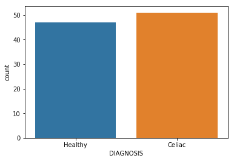

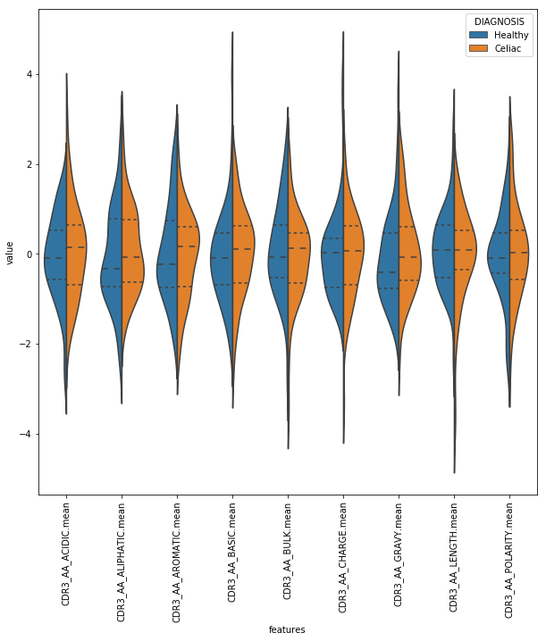

```python
df_gene = df_per_target

df_gene.rename(columns={'CLIN': 'DIAGNOSIS'}, inplace=True) # change CLIN to diagnosis
# cout raws per diagnosis class
ax = sns.countplot(df_gene['DIAGNOSIS'],label="Count")
C, H = df_gene['DIAGNOSIS'].value_counts()
print('Number of Celiac: ',C)
print('Number of Healthy : ',H)
print('Difference:',(C-H))
print('percentage: ', (C-H)/C)

#seaborn graph
data = df_gene
# y includes our labels and x includes our features
y = data.DIAGNOSIS
# get the cols with the string '.mean'
means_cols = [col for col in df_per_target.columns if '.mean' in col]
data_features =data.loc[:, means_cols]
# standardization
data_n_2 = (data_features - data_features.mean()) / (data_features.std())
# binding data
data_features = pd.concat([y,data_n_2],axis=1)

#create graph
data_features = pd.melt(data_features,id_vars="DIAGNOSIS",
                    var_name="features",
                    value_name='value')
plt.figure(figsize=(10,10))
sns.violinplot(x="features", y="value", hue="DIAGNOSIS", data=data_features ,split=True, inner="quartile")
plt.xticks(rotation=90)
```

Unlike what we thought, these features do not seem to provide significant information. However, we may notice that there may be relevant information in the tails of distributions. Thus, we decided to create a new features that represent the 75%('quter'), 95%('tail'), and str of each CDR3 property distribution. Lets see what we get from this features' distributions:

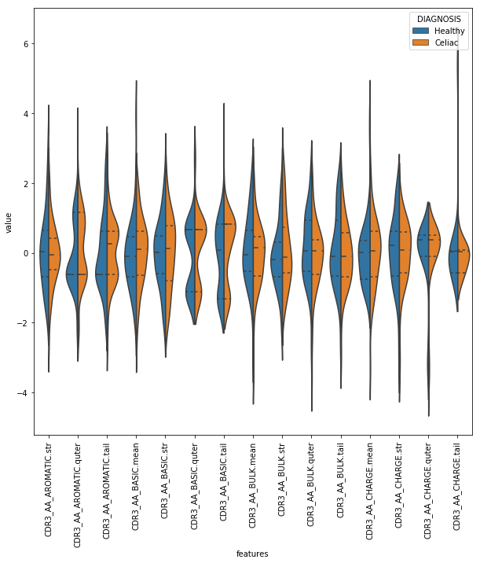

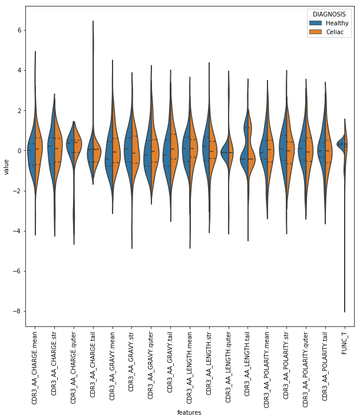

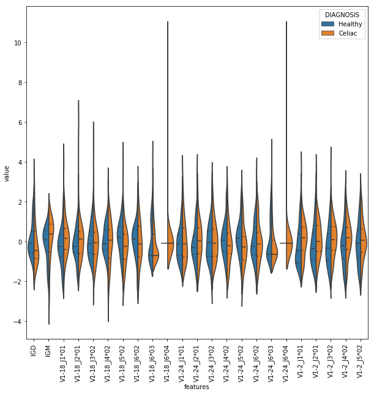

```python
df_gene = df_per_target
df_gene.rename(columns={'CLIN': 'DIAGNOSIS'}, inplace=True) # change CLIN to diagnosis
#seaborn graph
data = df_gene
# y includes our labels and x includes our features
y = data.DIAGNOSIS
data_features =data.loc[:,'CDR3_AA_AROMATIC.str':'CDR3_AA_CHARGE.tail']
# standardization
data_n_2 = (data_features - data_features.mean()) / (data_features.std())
# binding diagnosis and features data
data_features = pd.concat([y,data_n_2],axis=1)
data_features = pd.melt(data_features,id_vars="DIAGNOSIS",
                    var_name="features",
                    value_name='value')
#create graph
plt.figure(figsize=(10,10))
sns.violinplot(x="features", y="value", hue="DIAGNOSIS", data=data_features ,split=True, inner="quartile")
plt.xticks(rotation=90)

######################
data_features =data.loc[:,'CDR3_AA_CHARGE.mean':'FUNC_T']
# standardization
data_n_2 = (data_features - data_features.mean()) / (data_features.std())
# binding diagnosis and features data
data_features = pd.concat([y,data_n_2],axis=1)
data_features = pd.melt(data_features,id_vars="DIAGNOSIS",
                    var_name="features",
                    value_name='value')
#create graph
plt.figure(figsize=(10,10))
sns.violinplot(x="features", y="value", hue="DIAGNOSIS", data=data_features ,split=True, inner="quartile")
plt.xticks(rotation=90)

#####################
data_features =data.loc[:,'IGD':'V1-2_J5*02']
# standardization
data_n_2 = (data_features - data_features.mean()) / (data_features.std())
# binding diagnosis and features data
data_features = pd.concat([y,data_n_2],axis=1)
data_features = pd.melt(data_features,id_vars="DIAGNOSIS",
                    var_name="features",
                    value_name='value')
#create graph
plt.figure(figsize=(10,10))
sns.violinplot(x="features", y="value", hue="DIAGNOSIS", data=data_features ,split=True, inner="quartile")
plt.xticks(rotation=90)
```

We can recognize more diffrent between the distribution that represent the tails and str.

## 2.2 Kolmogorov Smirnov test (example)

In order to quantify the results we use the KS test.

If the K-S statistic is small or the p-value is high, then we cannot reject the hypothesis that the distributions of the two samples are the same.

```python
# Lets exam the KS of most different distribution as visualize above :
from scipy import stats
#create distribution for healthy and celiac
df_per_target = pd.read_pickle('VDJ_CDR3_FUNC_ISOTYPE_DseqL')
data_features = df_per_target
dist_healthy = data_features.loc[data_features['CLIN']== 'Healthy']
dist_celiac = data_features.loc[data_features['CLIN']== 'Celiac']

#KS test
dist_healthy_acid = dist_healthy.loc[:,'CDR3_AA_ALIPHATIC.quter']
dist_celiac_acid = dist_celiac.loc[:,'CDR3_AA_ALIPHATIC.quter']
print(stats.ks_2samp(dist_healthy_acid, dist_celiac_acid) )
dist_healthy_acid = dist_healthy.loc[:,'CDR3_AA_ALIPHATIC.tail']
dist_celiac_acid = dist_celiac.loc[:,'CDR3_AA_ALIPHATIC.tail']
print(stats.ks_2samp(dist_healthy_acid, dist_celiac_acid) )
dist_healthy_acid = dist_healthy.loc[:,'CDR3_AA_AROMATIC.mean']
dist_celiac_acid = dist_celiac.loc[:,'CDR3_AA_AROMATIC.mean']
print(stats.ks_2samp(dist_healthy_acid, dist_celiac_acid) )
dist_healthy_acid = dist_healthy.loc[:,'CDR3_AA_BULK.quter']
dist_celiac_acid = dist_celiac.loc[:,'CDR3_AA_BULK.quter']
print(stats.ks_2samp(dist_healthy_acid, dist_celiac_acid) )
dist_healthy_acid = dist_healthy.loc[:,'FUNC_T']
dist_celiac_acid = dist_celiac.loc[:,'FUNC_T']
score = stats.ks_2samp(dist_healthy_acid, dist_celiac_acid)
print(score )
```

```
Ks_2sampResult(statistic=0.19357530246141008, pvalue=0.28655599790196024)
Ks_2sampResult(statistic=0.17062995410930332, pvalue=0.43818466495466946)
Ks_2sampResult(statistic=0.182311222361285, pvalue=0.35580004036288754)
Ks_2sampResult(statistic=0.20650813516896116, pvalue=0.21957487476161328)
Ks_2sampResult(statistic=0.18439716312056736, pvalue=0.34220540082273715)
```

#### 2.2.1 let's extract the features with informative distribution(diffrent pattern between cohorts) by loop of calculation KS test and save the ones that have a low pvalue (Pvalue<0.05).

```python
# Lets exam the KS of most different distribution (pvalue<0.05):
from scipy import stats

#separate data for healthy and celiac
df_per_target = pd.read_pickle('VDJ_CDR3_FUNC_ISOTYPE_DseqL') #load data
data_features = df_per_target
dist_healthy = data_features.loc[data_features['CLIN']== 'Healthy']
dist_celiac = data_features.loc[data_features['CLIN']== 'Celiac']

# loop for calculate KS for all the features and save those with pvalue < 0.05
informative_columns_idx = []
informative_columns = []
df = df_per_target
for idx_col in range(3,1046):
    dist_healthy_acid = dist_healthy.iloc[:,idx_col]
    dist_celiac_acid = dist_celiac.iloc[:,idx_col]
    score = stats.ks_2samp(dist_healthy_acid, dist_celiac_acid)
    if score.pvalue < 0.05 :
        print(df.columns[idx_col])
        print(stats.ks_2samp(dist_healthy_acid, dist_celiac_acid) )
        #save the index columns and names
        informative_columns_idx.append(idx_col)
        informative_columns.append(df.columns[idx_col])
```

```
V6
Ks_2sampResult(statistic=0.2966207759699624, pvalue=0.021025484202870023)
J1
Ks_2sampResult(statistic=0.30496453900709225, pvalue=0.016213810803922094)
V6-1
Ks_2sampResult(statistic=0.2966207759699624, pvalue=0.021025484202870023)
D2-2
Ks_2sampResult(statistic=0.27075511055486023, pvalue=0.04494855481482068)
D3-9
Ks_2sampResult(statistic=0.27075511055486023, pvalue=0.04494855481482068)
V3_J1_x
Ks_2sampResult(statistic=0.3166458072590739, pvalue=0.011133201202406741)
V3_J2_x
Ks_2sampResult(statistic=0.2757613683771381, pvalue=0.03901211431441744)
V6_J6_x
Ks_2sampResult(statistic=0.3216520650813517, pvalue=0.009435629435730303)
V2-5*01
Ks_2sampResult(statistic=0.2774301209845641, pvalue=0.037191481629615886)
V6-1*01
Ks_2sampResult(statistic=0.2966207759699624, pvalue=0.021025484202870023)
D3-9*01
Ks_2sampResult(statistic=0.27075511055486023, pvalue=0.04494855481482068)
J1*01
Ks_2sampResult(statistic=0.34918648310387984, pvalue=0.003626221313866333)
IGD
Ks_2sampResult(statistic=0.2891113892365457, pvalue=0.026402426159679)
IGM
Ks_2sampResult(statistic=0.2857738840216938, pvalue=0.029159785368225687)
V1-24_J5*02
Ks_2sampResult(statistic=0.277430120984564, pvalue=0.03719148162961597)
V1-2_J1*01
Ks_2sampResult(statistic=0.2820191906549854, pvalue=0.03256255607933538)
V2-5_J3*02
Ks_2sampResult(statistic=0.3149770546516479, pvalue=0.011757617473883406)
V3-11_J3*02
Ks_2sampResult(statistic=0.2790988735919899, pvalue=0.03544558832981364)
V4-59_J1*01
Ks_2sampResult(statistic=0.3445974134334584, pvalue=0.004276035679453893)
V4-59_J2*01
Ks_2sampResult(statistic=0.295369211514393, pvalue=0.02184766861226789)
V4-61_J3*02
Ks_2sampResult(statistic=0.27409261576971217, pvalue=0.040910068401477644)
V6-1_J3*02
Ks_2sampResult(statistic=0.27576136837713805, pvalue=0.03901211431441754)
```

The statistic value is the absolute max distance (supremum) between the CDFs of the two samples. The closer this number is to 0 the more likely it is that the two samples were drawn from the same distribution. We can reject the null hypothesis that the two samples were drawn from the same distribution if the p-value is less than our significance level.

Print and save variable of informative_columns according to KS test (p_value <0.05)

```python
# print and save variable of informative_columns according to KS test (p_value <0.05)
print(informative_columns)
print(informative_columns_idx)
```

[output not shown]

#### 2.2.2 Visualization of the diffrent distributon features by violin graph

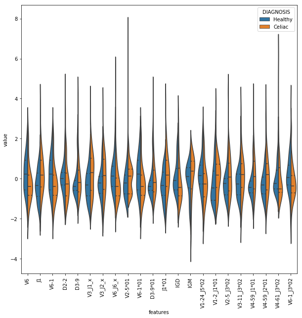

```python
# visualize the distibution by violin graph
df_gene = df_per_target
df_gene.rename(columns={'CLIN': 'DIAGNOSIS'}, inplace=True) # change CLIN to diagnosis
#seaborn graph
data = df_gene
# y includes our labels and x includes our features
y = data.DIAGNOSIS
data_features =data.iloc[:,informative_columns_idx]
# standardization
data_n_2 = (data_features - data_features.mean()) / (data_features.std())
# binding diagnosis and features data
data_features = pd.concat([y,data_n_2],axis=1)
data_features = pd.melt(data_features,id_vars="DIAGNOSIS",
                    var_name="features",
                    value_name='value')
#create graph
plt.figure(figsize=(10,10))
sns.violinplot(x="features", y="value", hue="DIAGNOSIS", data=data_features ,split=True, inner="quartile")
plt.xticks(rotation=90)
```

# Step 3: Feature Selection - 2 methods

Due to we seem to have informative results from the KS test, we think to build code for feature selection based on KS test.

## 3.1. Feature Selection- Our New Method - based on KS test

```python
# import packages
from scipy import stats #for KS test
import collections # for find duplicate variables
from sklearn.model_selection import train_test_split
import numpy as np
import pandas as pd
from collections import Counter

# load data
df= pd.read_pickle('VDJ_CDR3_FUNC_ISOTYPE_DseqL') #load data
X = df.iloc[:,3:]
y = df.loc[:,'CLIN']

# initialization
seed= 42
informative_columns = []
KS_fold_number = 10
subset_data_percent = 0.8
test_size_fold = 1-subset_data_percent

# loop for merge informative_features from each 10 different subset data.
# informative_features choose if for KS test between celiac&healty distribution
# the p_value is less then 0.05.
# in order to get different subset in each iteration we used different seeds
# for train_test_split function
for i in range(1,KS_fold_number):
    # split to 80% data [change seed in each iteration]
    x_train, x_test, y_train, y_test = train_test_split(X, y, test_size=test_size_fold, random_state=seed+i)
    xy_train_subset = x_train
    xy_train_subset.insert(loc=0,column='CLIN',value= list(y_train))
    #separate data to healthy and celiac data
    data_features = xy_train_subset
    dist_healthy = data_features.loc[data_features['CLIN']== 'Healthy']
    dist_celiac = data_features.loc[data_features['CLIN']== 'Celiac']
    # loop for calculate KS test(for each feature name) between Celiac to healthy feature's distribution.
    # and save feature names with pvalue < 0.05
    col_num = len(xy_train_subset.columns.values)
    for idx_col in range(1,col_num):
        dist_healthy_feature = dist_healthy.iloc[:,idx_col]
        dist_celiac_feature = dist_celiac.iloc[:,idx_col]
        score = stats.ks_2samp(dist_healthy_feature, dist_celiac_feature)
        if score.pvalue < 0.05 :
            # save columns names of informative features for this xy_train iteration
            informative_columns.append(xy_train_subset.columns[idx_col])
            # if you want to print each iteration results:
             ##print(xy_train_subset.columns[idx_col])
             ##print(stats.ks_2samp(dist_healthy_feature, dist_celiac_feature) )



# Choose the duplicate features
import collections
a = informative_columns
# save list with count numbers of duplicate features
informative_duplicate_count = pd.Series(a).value_counts()
vc = informative_duplicate_count
# save list of duplicate features's names in decending order
informative_features_after_KS_folds_80 = vc[vc > 2].index.tolist()
# print final result:
print(informative_features_after_KS_folds_80)
print(informative_duplicate_count)
```

```
['J1*01', 'V4-59_J1*01', 'V3_J1_x', 'V6_J6_x', 'J1', 'V1-3', 'V6', 'V6-1_J3*02', 'V6-1*01', 'V6-1', 'V3-11_J3*02', 'V4-61_J3*02', 'V3_J6_x', 'D3-9', 'V5_J1_x', 'V3_J2_x', 'V2-5_J3*02', 'IGM', 'D3-9*01', 'V3-49*03', 'V1-3*01', 'V3_J3_x', 'V1-24_J5*02', 'V3-48*01', 'V1-3_J4*02', 'V1-2_J1*01']
J1*01                 9
V4-59_J1*01           9
V3_J1_x               8
V6_J6_x               8
J1                    7
V1-3                  5
V6                    5
V6-1_J3*02            5
V6-1*01               5
V6-1                  5
V3-11_J3*02           5
V4-61_J3*02           4
V3_J6_x               4
D3-9                  4
V5_J1_x               4
V3_J2_x               4
V2-5_J3*02            4
IGM                   4
D3-9*01               4
V3-49*03              3
V1-3*01               3
V3_J3_x               3
V1-24_J5*02           3
V3-48*01              3
V1-3_J4*02            3
V1-2_J1*01            3
V3-64_J1*01           2
IGD                   2
D2-2                  2
V2-5*01               2
                     ..
V1-46*03              2
V3-21_J5*02           1
V3-43                 1
V6-1_J6*02            1
J3*02                 1
V1-8_J4*02            1
6.0-DseqL             1
V4-4                  1
```

[output cut: 8 more lines]

```
V3-11_J2*01           1
V5-10-1_J6*02         1
V3-13_J4*02           1
V4-61_J5*02           1
90-JL                 1
V3-7_J5*02            1
V2_J4_x               1
19.0-DseqL            1
V4-59_J3*02           1
V1-18_J5*02           1
V1-8*01               1
J6                    1
V1-2_J4*02            1
V1-45_J4*02           1
Length: 73, dtype: int64
```

### 3.1.1 compare performance between training set and test set (fold=1)

```python
# load data
df= pd.read_pickle('VDJ_CDR3_FUNC_ISOTYPE_DseqL') #load data
X = df.iloc[:,3:]
y = pd.factorize(df_rf['CLIN'])[0]

# initialization
seed= 42
informative_columns = []
KS_fold_number = 2
subset_data_percent = 0.8
test_size_fold = 1-subset_data_percent

# loop for merge informative_features from each 10 different subset data.
# informative_features choose if for KS test between celiac&healty distribution
# the p_value is less then 0.05.
# in order to get different subset in each iteration we used different seeds
# for train_test_split function
for i in range(1,KS_fold_number):
    # split to 80% data [change seed in each iteration]
    x_train, x_test, y_train, y_test = train_test_split(X, y, test_size=test_size_fold, random_state=seed+i)
    xy_train_subset = x_train
    xy_train_subset.insert(loc=0,column='CLIN',value= list(y_train))
    #separate data to healthy and celiac data
    data_features = xy_train_subset
    dist_healthy = data_features.loc[data_features['CLIN']== 1]
    dist_celiac = data_features.loc[data_features['CLIN']== 0]
    # loop for calculate KS test(for each feature name) between Celiac to healthy feature's distribution.
    # and save feature names with pvalue < 0.05
    col_num = len(xy_train_subset.columns.values)
    for idx_col in range(1,col_num):
        dist_healthy_feature = dist_healthy.iloc[:,idx_col]
        dist_celiac_feature = dist_celiac.iloc[:,idx_col]
        score = stats.ks_2samp(dist_healthy_feature, dist_celiac_feature)
        if score.pvalue < 0.05:
            # save columns names of informative features for this xy_train iteration
            informative_columns.append(xy_train_subset.columns[idx_col])
            # if you want to print each iteration results:
             ##print(xy_train_subset.columns[idx_col])
             ##print(stats.ks_2samp(dist_healthy_feature, dist_celiac_feature) )

# check performance
#clf = RandomForestClassifier(n_)
clf = RandomForestClassifier(n_estimators=100, random_state=42, max_depth=3)
clf.fit(x_train.loc[:,informative_columns], y_train)
train_pred = clf.predict_proba(x_train.loc[:,informative_columns])
print('Accuracy on training set: {}'.format(roc_auc_score(y_train, train_pred[:,1])))

test_pred = clf.predict_proba(x_test.loc[:,informative_columns])
print('Accuracy on test set: {}'.format(roc_auc_score(y_test, test_pred [:,1])))
```

```
Accuracy on training set: 0.9946127946127946
Accuracy on test set: 0.6190476190476191
```

### 3.1.2. Visualize the impact of feature selected used PCA (Principal component Analysis)

Because it difficult to visualize high dimensional data, we can use PCA to find the first two principal components. By doing so, we can visualize the data in 2 dimensions for more intuitive look.

PCA for the informative columns (after KS test)

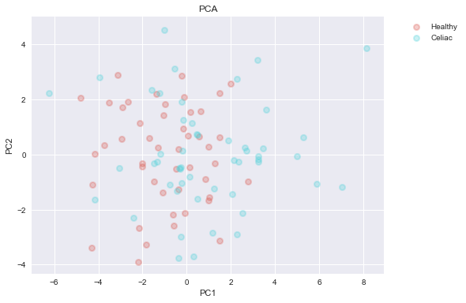

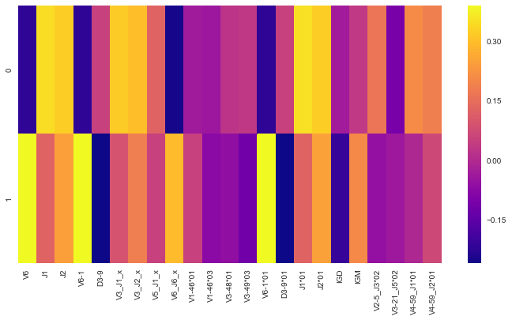

```python
df = pd.read_pickle('VDJ_CDR3_FUNC_ISOTYPE_DseqL')

# First, we'll need to scale our data so that each feature has a single unit variance.
from sklearn.preprocessing import scale
scaled_data = scale(df.loc[:,informative_columns])


# cellLabels = target_name (H / C)
cellLabels = df.loc[:,'CLIN']
Counter(cellLabels)
target_name = df.CLIN.unique()

#%% PCA:
pca = PCA(n_components=2)
#Now we can transform this data to its first 2 principal components.
X_r = pca.fit_transform(scaled_data )

plt.figure(figsize=(8,6))
colors = sns.color_palette("hls", len(cellLabels.unique()))
lw = 2
for color,  target_name in zip(colors,cellLabels.unique() ) :
    IDX = [i for i,x in enumerate(cellLabels) if x==target_name]
    plt.scatter(X_r[IDX, 0], X_r[IDX, 1], color=color, alpha=.3, lw=lw,
                label=target_name)
plt.legend(loc=2, scatterpoints=1,bbox_to_anchor=(1.05, 1))
plt.xlabel('PC1')
plt.ylabel('PC2')
plt.title('PCA');

# Heat map
df_columns = df.loc[:,informative_columns].columns.values
df_comp = pd.DataFrame(pca.components_,columns=df_columns)
plt.figure(figsize=(12,6))
sns.heatmap(df_comp,cmap='plasma',)
```

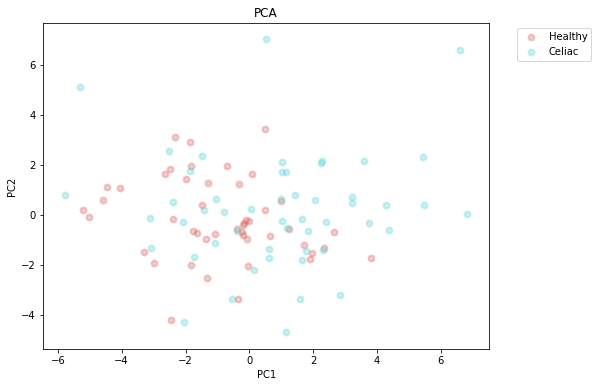

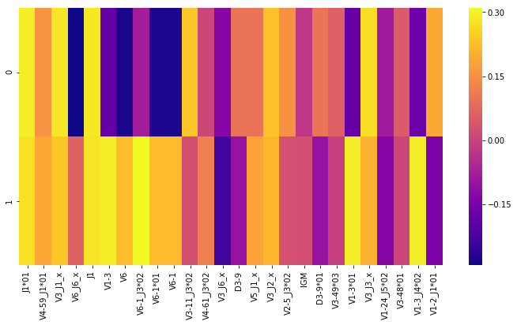

```python
df = pd.read_pickle('VDJ_CDR3_FUNC_ISOTYPE_DseqL')

# First, we'll need to scale our data so that each feature has a single unit variance.
from sklearn.preprocessing import scale
scaled_data = scale(df.loc[:,informative_features_after_KS_folds_80])


# cellLabels = target_name (H / C)
cellLabels = df.loc[:,'CLIN']
Counter(cellLabels)
target_name = df.CLIN.unique()

#%% PCA:
pca = PCA(n_components=2)
#Now we can transform this data to its first 2 principal components.
X_r = pca.fit_transform(scaled_data )

plt.figure(figsize=(8,6))
colors = sns.color_palette("hls", len(cellLabels.unique()))
lw = 2
for color,  target_name in zip(colors,cellLabels.unique() ) :
    IDX = [i for i,x in enumerate(cellLabels) if x==target_name]
    plt.scatter(X_r[IDX, 0], X_r[IDX, 1], color=color, alpha=.3, lw=lw,
                label=target_name)
plt.legend(loc=2, scatterpoints=1,bbox_to_anchor=(1.05, 1))
plt.xlabel('PC1')
plt.ylabel('PC2')
plt.title('PCA');

# Heat map
df_columns = df.loc[:,informative_features_after_KS_folds_80].columns.values
df_comp = pd.DataFrame(pca.components_,columns=df_columns)
plt.figure(figsize=(12,6))
sns.heatmap(df_comp,cmap='plasma',)
```

This heatmap and the color bar basically represent the correlation between the various feature and the principal component itself.

- For PC1>0, the majority of points are blue(i.e Celiac patients).
- Hence, We can create a new feature that will contain this information, means that, PC1 => 0 represent by 1, and PC1<0 by 0. [I don't use it because I don't sure if these features are not bias features]

```python
pca.explained_variance_ratio_
```

```
array([0.25143114, 0.15215971])
```

we can see that the first principal component contains 25.14% of the variance and the second principal component contains 15.21% of the variance. Together, the two components contain 40.35% of the information.

## 3.2 Extract important features used Random Forest

**In order to recognize features with high importance score over the 10 folds, We create visualization graph of features importance for each fold**. Finally, we calculate the mean importances of each feature over all the folds and then sort it by descending order.

#### Tuned Hyperparameters

Because feature importances are varying a lot when we used random forest without custom settings [See at 'Whole_Workflow' notebook], we decided to increase the **number of trees**, e.g: 100 to 1000 or 10000. There is no risk of overfitting in random forest with growing number of trees, as they are trained independently from each other.

If feature importances are still varying a lot, features are likely to be redundant (like: feature A gives same amount of information gain as features B and C together)

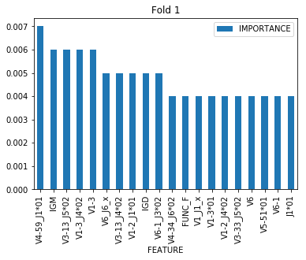

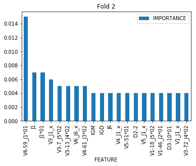

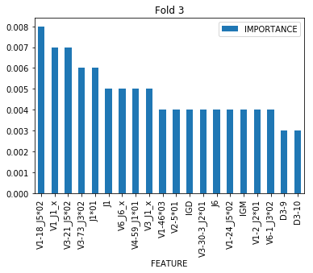

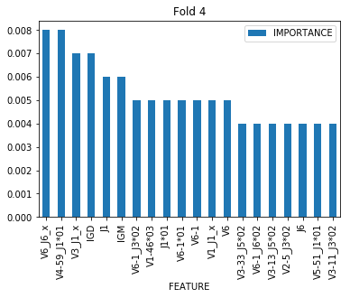

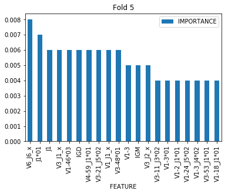

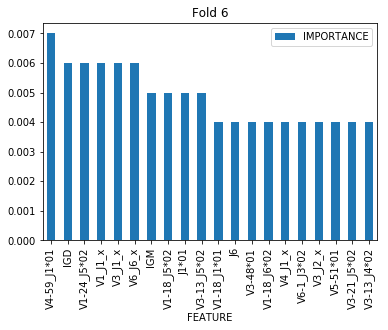

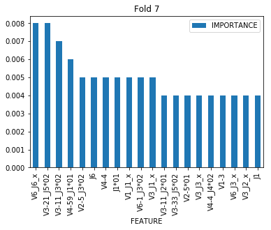

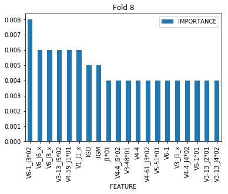

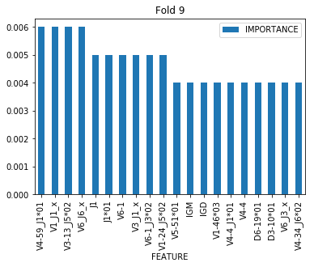

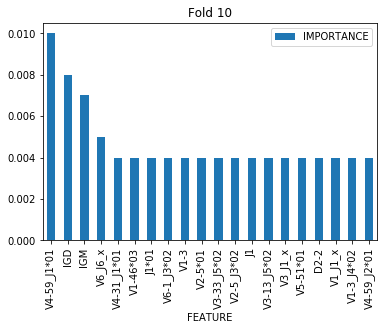

```
The mean importances of each feature over all the folds
             IMPORTANCE
FEATURE
V4-59_J1*01      0.0076
V6_J6_x          0.0062
IGD              0.0053
V1_J1_x          0.0053
J1*01            0.0052
V3_J1_x          0.0051
IGM              0.0050
J1               0.0048
V3-21_J5*02      0.0045
V6-1_J3*02       0.0045
V3-13_J5*02      0.0044
V1-46*03         0.0038
V6-1*01          0.0037
V1-24_J5*02      0.0037
V6-1             0.0037
V6               0.0036
V1-18_J5*02      0.0036
V5-51*01         0.0036
V3-11_J3*02      0.0035
V2-5_J3*02       0.0034
```

```python
#Visualize features importance for each fold by random forest

import numpy as np
import matplotlib.pyplot as plt
from sklearn.ensemble import RandomForestClassifier
from sklearn.model_selection import KFold
from sklearn.datasets import make_classification

# load data
df_rf = pd.read_pickle('VDJ_CDR3_FUNC_ISOTYPE_DseqL')

# splitting to features_data and target
data_x = df_rf.iloc[:,3:]
feature_names = data_x.columns
data_y = pd.factorize(df_rf['CLIN'])[0]

# define K-fold and random forest classifier
kf = KFold(n_splits=10,shuffle = True)
rfc = RandomForestClassifier(n_estimators=10000)
# initialize variables for loop
count = 1
all_importances = pd.DataFrame()
# test data is not needed for fitting
for train, _ in kf.split(data_x, data_y):
    rfc.fit(data_x.iloc[train,:], data_y[train])
    # sort the feature index by importance score in descending order
    importances_index_desc = np.argsort(rfc.feature_importances_)[::-1]
    feature_labels = [feature_names[i] for i in importances_index_desc]
    importances1 = pd.DataFrame({'FEATURE':data_x.columns,'IMPORTANCE':np.round(rfc.feature_importances_,3)})
    importances = importances1.sort_values('IMPORTANCE',ascending=False).set_index('FEATURE')
    # append importance features of all the folds
    all_importances = all_importances.append(importances1)

    # plot
    plt.figure()
    importances[0:20].plot.bar()
    plt.title('Fold {}'.format(count))
    count = count + 1
plt.show()

# Lets calculate the mean importances of each feature over all the folds and then sort it by descending order.
all_importances_mean = all_importances.groupby('FEATURE').mean()
all_importances_sort = all_importances_mean.sort_values('IMPORTANCE',ascending=False)
print('The mean importances of each feature over all the folds')
# print list of the best importances features
print(all_importances_sort[0:20])
```

```python
# save the most important list to variable
rf_features_importance = all_importances_sort
rf_important_features_list = list(rf_features_importance.index)
print(rf_important_features_list[0:30])
```

[output not shown]

### select features used training set and check performance with compare to testing set

```python
# optimize parameters for Random
```

```python
from sklearn.metrics import roc_auc_score
from sklearn.metrics import confusion_matrix
from sklearn.metrics import f1_score
from sklearn.metrics import precision_score
from sklearn.metrics import accuracy_score

F1_sum = 0
seed = 42
seed_vector = [10,3,0,2,-5,9]
for i in seed_vector :
        df = pd.read_pickle('VDJ_CDR3_FUNC_ISOTYPE_DseqL')

        train_features, test_features, train_labels, test_labels = train_test_split(
                                            df.iloc[:,3:], pd.factorize(df_rf['CLIN'])[0],test_size=0.3, random_state=seed + i )
        # select important features
        feature_selector = RandomForestClassifier(n_estimators=100)

        features = feature_selector.fit(train_features, train_labels)

        # sort the feature index by importance score in descending order
        importances_index_desc = np.argsort(feature_selector.feature_importances_)[::-1]
        feature_labels = [feature_names[i] for i in importances_index_desc]
        importances1 = pd.DataFrame({'FEATURE':data_x.columns,'IMPORTANCE':np.round(rfc.feature_importances_,3)})
        importances = importances1.sort_values('IMPORTANCE',ascending=False).set_index('FEATURE')
        # columns' names of importnt features (take the first 30)
        filtered_features = list(rf_features_importance.index)[0:30]
        # Now to see the classification performance of the random forest using important features
        #clf = RandomForestClassifier(n_estimators=100, random_state=23, max_depth=3)
        clf = GaussianNB()
        clf.fit(train_features.loc[:,filtered_features], train_labels)

        print('~~~~~~~~~~~~~~~~~~~~seed: ',seed+i,'~~~~~~~~~~~~~~~~~~~~~~~~~~')

        print(' \n \n ~~~~For Train Set~~~~')
        train_pred = clf.predict(train_features.loc[:,filtered_features])
        print('Roc_auc on training set: {}'.format(roc_auc_score(train_labels, train_pred)))
        print('Confusion matrix on training set: \n ',(confusion_matrix(train_labels, train_pred)))
        print('F1 on training set: {}'.format(f1_score(train_labels, train_pred)))
        print('precision on training set: {}'.format(precision_score(train_labels, train_pred)))
        print('Accuracy on training set: {}'.format(accuracy_score(train_labels, train_pred)))

        F1_sum = F1_sum + f1_score(test_labels, test_pred)

        print(' \n \n ~~~~For Test Set~~~~')

        test_pred = clf.predict(test_features.loc[:,filtered_features])
        print('Roc_auc on test set: {}'.format(roc_auc_score(test_labels, test_pred )))
        print('Confision matrix on training set: \n', (confusion_matrix(test_labels, test_pred)))
        print('F1 on training set: {}'.format(f1_score(test_labels, test_pred)))
        print('precision on training set: {}'.format(precision_score(test_labels, test_pred)))
        print('Accuracy on training set: {}'.format(accuracy_score(test_labels, test_pred)))
        print('\n~~~~~~~~~~~~~~~~~~~~~~~~~~~~~~~~~~~~~~~~~~~~~~~~~~~~~~~~~~~~~~~~~')



F1_mean = F1_sum/ len(seed_vector)
print('F1 mean over ',len(seed_vector),' folds :' ,F1_mean)
```

```
~~~~~~~~~~~~~~~~~~~~seed:  52 ~~~~~~~~~~~~~~~~~~~~~~~~~~


 ~~~~For Train Set~~~~
Roc_auc on training set: 0.7965367965367965
Confusion matrix on training set:
  [[29  4]
 [10 25]]
F1 on training set: 0.7812500000000001
precision on training set: 0.8620689655172413
Accuracy on training set: 0.7941176470588235


 ~~~~For Test Set~~~~
Roc_auc on test set: 0.5758928571428572
Confision matrix on training set:
 [[10  4]
 [ 9  7]]
F1 on training set: 0.5185185185185185
precision on training set: 0.6363636363636364
Accuracy on training set: 0.5666666666666667

~~~~~~~~~~~~~~~~~~~~~~~~~~~~~~~~~~~~~~~~~~~~~~~~~~~~~~~~~~~~~~~~~
~~~~~~~~~~~~~~~~~~~~seed:  45 ~~~~~~~~~~~~~~~~~~~~~~~~~~


 ~~~~For Train Set~~~~
Roc_auc on training set: 0.7649122807017543
Confusion matrix on training set:
  [[23  7]
 [ 9 29]]
F1 on training set: 0.7837837837837838
precision on training set: 0.8055555555555556
Accuracy on training set: 0.7647058823529411


 ~~~~For Test Set~~~~
Roc_auc on test set: 0.6900452488687783
Confision matrix on training set:
 [[13  4]
```

[output cut: 84 more lines]

```
precision on training set: 0.8620689655172413
Accuracy on training set: 0.7647058823529411


 ~~~~For Test Set~~~~
Roc_auc on test set: 0.7901785714285714
Confision matrix on training set:
 [[15  1]
 [ 5  9]]
F1 on training set: 0.75
precision on training set: 0.9
Accuracy on training set: 0.8

~~~~~~~~~~~~~~~~~~~~~~~~~~~~~~~~~~~~~~~~~~~~~~~~~~~~~~~~~~~~~~~~~
F1 mean over  6  folds : 0.5043070355570356
```

You can see that the accuracy on training and test sets are not similar which means that our model maybe have overfitting.

```python
from sklearn.metrics import roc_auc_score
from sklearn.metrics import confusion_matrix
from sklearn.metrics import f1_score
from sklearn.metrics import precision_score
from sklearn.metrics import accuracy_score


df = pd.read_pickle('VDJ_CDR3_FUNC_ISOTYPE_DseqL')

train_features, test_features, train_labels, test_labels = train_test_split(
    df.iloc[:,3:], pd.factorize(df_rf['CLIN'])[0],test_size=0.3, random_state=42)
train_features.shape, test_features.shape

feature_selector = RandomForestClassifier(n_estimators=100)

features = feature_selector.fit(train_features, train_labels)

# sort the feature index by importance score in descending order
importances_index_desc = np.argsort(feature_selector.feature_importances_)[::-1]
feature_labels = [feature_names[i] for i in importances_index_desc]
importances1 = pd.DataFrame({'FEATURE':data_x.columns,'IMPORTANCE':np.round(rfc.feature_importances_,3)})
importances = importances1.sort_values('IMPORTANCE',ascending=False).set_index('FEATURE')
# columns' names of importnt features (take the first 30)
filtered_features = list(rf_features_importance.index)[0:30]
# Now to see the classification performance of the random forest using important features
#clf = RandomForestClassifier(n_estimators=100, random_state=23, max_depth=3)
clf = GaussianNB()
clf.fit(train_features, train_labels)

print(' \n \n ~~~~For Train Set~~~~')
train_pred = clf.predict(train_features)
print('Roc_auc on training set: {}'.format(roc_auc_score(train_labels, train_pred)))
print('Confusion matrix on training set: \n ',(confusion_matrix(train_labels, train_pred)))
print('F1 on training set: {}'.format(f1_score(train_labels, train_pred)))
print('precision on training set: {}'.format(precision_score(train_labels, train_pred)))
print('Accuracy on training set: {}'.format(accuracy_score(train_labels, train_pred)))



print(' \n \n ~~~~For Test Set~~~~')

test_pred = clf.predict(test_features)
print('Roc_auc on test set: {}'.format(roc_auc_score(test_labels, test_pred )))
print('Confision matrix on training set: \n', (confusion_matrix(test_labels, test_pred)))
print('F1 on training set: {}'.format(f1_score(test_labels, test_pred)))
print('precision on training set: {}'.format(precision_score(test_labels, test_pred)))
print('Accuracy on training set: {}'.format(accuracy_score(test_labels, test_pred)))
```

```
 ~~~~For Train Set~~~~
Roc_auc on training set: 0.8571428571428572
Confusion matrix on training set:
  [[33  0]
 [10 25]]
F1 on training set: 0.8333333333333333
precision on training set: 1.0
Accuracy on training set: 0.8529411764705882


 ~~~~For Test Set~~~~
Roc_auc on test set: 0.4732142857142857
Confision matrix on training set:
 [[ 8  6]
 [10  6]]
F1 on training set: 0.42857142857142855
precision on training set: 0.5
Accuracy on training set: 0.4666666666666667
```